# Bears ‘count’ too: quantity estimation and comparison in black bears, Ursus americanus - ScienceDirect

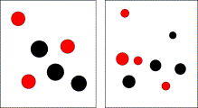

[figure not shown]

## [Animal Behaviour](https://www.sciencedirect.com/science/journal/00033472)

[Volume 84, Issue 1](https://www.sciencedirect.com/science/journal/00033472/84/1), July 2012, Pages 231-238

# Bears ‘count’ too: quantity estimation and comparison in black bears, *Ursus americanus*

[JenniferVonk<sup>a</sup>](https://www.sciencedirect.com/science/article/abs/pii/S0003347212002126?via%3Dihub#!)[Michael J.Beran<sup>b</sup><sup>1</sup>](https://www.sciencedirect.com/science/article/abs/pii/S0003347212002126?via%3Dihub#!)

Studies of bear cognition are notably missing from the comparative record despite bears' large relative brain size and interesting status as generalist carnivores facing complex foraging challenges, but lacking complex social structures. We investigated the numerical abilities of three [American black bears](https://www.sciencedirect.com/topics/agricultural-and-biological-sciences/american-black-bear), *Ursus Americanus*, by presenting discrimination tasks on a touch-screen computer. One bear chose the larger of two arrays of dot stimuli, while two bears chose the smaller array of dots. On some trials, the relative number of dots was congruent with the relative total area of the two arrays. On other trials, number of dots was incongruent with area. All of the bears were above chance on trials of both types with static dots. Despite encountering greater difficulty with dots that moved within the arrays, one bear was able to discriminate numerically larger arrays of moving dots, and a subset of moving dots from within the larger array, even when area and number were incongruent. Thus, although the bears used area as a cue to guide their responses, they were also able to use number as a cue. The pattern of performance was similar to that found previously with monkeys, and suggests that bears may also show other forms of sophisticated quantitative abilities.

### Highlights

► This is the first demonstration of quantity estimation in bears. ► A nonsocial species can enumerate moving stimuli and subsets of stimuli. ► Bears predominantly appeared to use area but could also use number as a cue. ► Bears showed effects of ratio and difference comparable to those of primates. ► Bears performed ‘better’ when choosing ‘larger’ relative to ‘smaller’ amounts.

## Keywords

area

bear

number

quantity estimation

ratio

*Ursus americanus*

*E-mail address:* mjberan@yahoo.com (M. J. Beran).

Published by Elsevier Ltd.